# Data Cleaning Practice

PM

2023-07-31

## Data Cleaning Practice Markdown

This is a R markdown of important data cleaning code for future projects. For more information on creating a markdown visit: http://rmarkdown.rstudio.com.

## Important packages

```r
library("tibble")
library("tidyr")
library("ggplot2")
library("eeptools")
print("Done")
```

```
## [1] "Done"
```

## Getting the data

```r
library(readr)
my_fake_demographics <- read_csv("my_fake_demographics.csv")
View(my_fake_demographics)
dem.df2 <- my_fake_demographics # Keep the name simple
head(dem.df2)
```

| PAT_MRN | PAT_DOB | RACE | ETHNICITY | SEX |
| --- | --- | --- | --- | --- |
| 923 | 4/5/2007 | White | Not Hispanic or Latino | Female |
| 942 | 9/1/2006 | NA | NA | Female |
| 356 | 11/26/2000 | White | Not Hispanic or Latino | Male |
| 844 | 11/28/2004 | Other | Not Hispanic or Latino | Female |
| 675 | 3/3/2013 | Black or African-American | Not Hispanic or Latino | Male |
| 564 | 12/13/2013 | White | Not Hispanic or Latino | Female |

```r
summary(dem.df2)
```

```
##     PAT_MRN        PAT_DOB              RACE            ETHNICITY
##  Min.   :100.0   Length:300         Length:300         Length:300
##  1st Qu.:311.5   Class :character   Class :character   Class :character
##  Median :548.0   Mode  :character   Mode  :character   Mode  :character
##  Mean   :548.7
##  3rd Qu.:760.2
##  Max.   :996.0
##      SEX
##  Length:300
##  Class :character
##  Mode  :character
##
##
##
```

```r
str(dem.df2)
```

```
## spc_tbl_ [300 × 5] (S3: spec_tbl_df/tbl_df/tbl/data.frame)
##  $ PAT_MRN  : num [1:300] 923 942 356 844 675 564 758 220 686 728 ...
##  $ PAT_DOB  : chr [1:300] "4/5/2007" "9/1/2006" "11/26/2000" "11/28/2004" ...
##  $ RACE     : chr [1:300] "White" NA "White" "Other" ...
##  $ ETHNICITY: chr [1:300] "Not Hispanic or Latino" NA "Not Hispanic or Latino" "Not Hispanic or Latino" ...
##  $ SEX      : chr [1:300] "Female" "Female" "Male" "Female" ...
##  - attr(*, "spec")=
##   .. cols(
##   ..   PAT_MRN = col_double(),
##   ..   PAT_DOB = col_character(),
##   ..   RACE = col_character(),
##   ..   ETHNICITY = col_character(),
##   ..   SEX = col_character()
##   .. )
##  - attr(*, "problems")=<externalptr>
```

```r
names(dem.df2)
```

```
## [1] "PAT_MRN"   "PAT_DOB"   "RACE"      "ETHNICITY" "SEX"
```

I can see the dimensions, categories, values, and stats of the data

## Missing values

```r
sapply(dem.df2, function(x) sum(is.na(x)))
```

```
##   PAT_MRN   PAT_DOB      RACE ETHNICITY       SEX
##         0         0        10         9         1
```

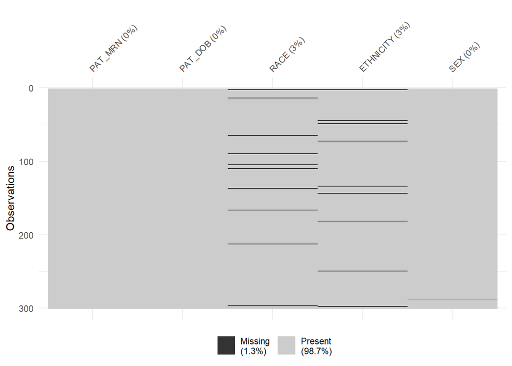

```r
library("visdat")
vis_miss(dem.df2)
```

## Imputation

Now lets correct the missing values in “RACE”, “ETHNICITY”, and “SEX”.

```r
dem.df2[!complete.cases(dem.df2),] # show rows with missing values
```

| PAT_MRN | PAT_DOB | RACE | ETHNICITY | SEX |
| --- | --- | --- | --- | --- |
| 942 | 9/1/2006 | NA | NA | Female |
| 929 | 6/10/2007 | NA | Not Hispanic or Latino | Male |
| 934 | 5/10/2005 | White | NA | Male |
| 645 | 7/21/2005 | More Than One Race | NA | Male |
| 574 | 7/14/2014 | NA | Not Hispanic or Latino | Male |
| 216 | 10/7/2004 | White | NA | Male |
| 169 | 6/28/2002 | NA | Not Hispanic or Latino | Male |
| 922 | 3/1/2006 | NA | Not Hispanic or Latino | Male |
| 524 | 3/28/2001 | NA | Not Hispanic or Latino | Female |
| 818 | 3/24/2001 | Other | NA | Female |

[output cut: 9 more lines]

# Ttanic data

These are the packages needed for the next part (imputation)

```r
library(ggplot2)
library(dplyr)
library(titanic)
library(cowplot)

titanic_train$Age
```

```
##   [1] 22.00 38.00 26.00 35.00 35.00    NA 54.00  2.00 27.00 14.00  4.00 58.00
##  [13] 20.00 39.00 14.00 55.00  2.00    NA 31.00    NA 35.00 34.00 15.00 28.00
##  [25]  8.00 38.00    NA 19.00    NA    NA 40.00    NA    NA 66.00 28.00 42.00
##  [37]    NA 21.00 18.00 14.00 40.00 27.00    NA  3.00 19.00    NA    NA    NA
##  [49]    NA 18.00  7.00 21.00 49.00 29.00 65.00    NA 21.00 28.50  5.00 11.00
##  [61] 22.00 38.00 45.00  4.00    NA    NA 29.00 19.00 17.00 26.00 32.00 16.00
##  [73] 21.00 26.00 32.00 25.00    NA    NA  0.83 30.00 22.00 29.00    NA 28.00
##  [85] 17.00 33.00 16.00    NA 23.00 24.00 29.00 20.00 46.00 26.00 59.00    NA
##  [97] 71.00 23.00 34.00 34.00 28.00    NA 21.00 33.00 37.00 28.00 21.00    NA
## [109] 38.00    NA 47.00 14.50 22.00 20.00 17.00 21.00 70.50 29.00 24.00  2.00
## [121] 21.00    NA 32.50 32.50 54.00 12.00    NA 24.00    NA 45.00 33.00 20.00
## [133] 47.00 29.00 25.00 23.00 19.00 37.00 16.00 24.00    NA 22.00 24.00 19.00
## [145] 18.00 19.00 27.00  9.00 36.50 42.00 51.00 22.00 55.50 40.50    NA 51.00
## [157] 16.00 30.00    NA    NA 44.00 40.00 26.00 17.00  1.00  9.00    NA 45.00
## [169]    NA 28.00 61.00  4.00  1.00 21.00 56.00 18.00    NA 50.00 30.00 36.00
```

[output cut: 60 more lines]

```r
sapply(titanic_train, function(x) sum(is.na(x)))
```

```
## PassengerId    Survived      Pclass        Name         Sex         Age
##           0           0           0           0           0         177
##       SibSp       Parch      Ticket        Fare       Cabin    Embarked
##           0           0           0           0           0           0
```

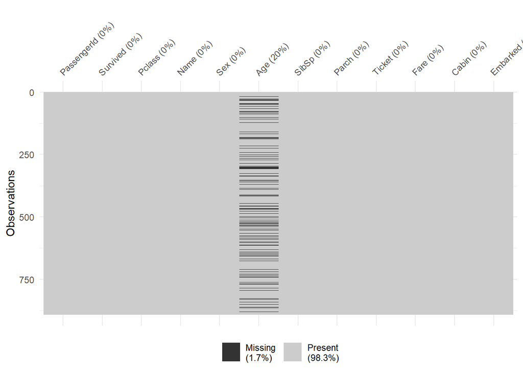

```r
library("visdat")
vis_miss(titanic_train)
```

# Simple Imputation

The value_imputed variable will store a data.frame of the imputed ages. The imputation itself boils down to replacing a column subset that has a value of NA with the value of our choice. This will be:

Zero: constant imputation, feel free to change the value. Mean (average): average age after when all NA’s are removed. Median: median age after when all NA’s are removed. ## Visualize variable distribution This step is important to compare variables before and after imputation.

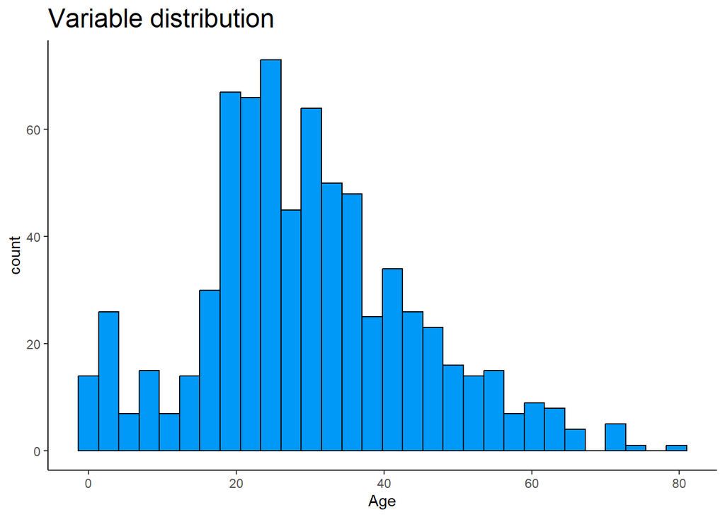

```r
ggplot(titanic_train, aes(Age)) +
  geom_histogram(color = "#000000", fill = "#0099F8") +
  ggtitle("Variable distribution") +
  theme_classic() +
  theme(plot.title = element_text(size = 18))
```

```r
value_imputed <- data.frame(
  original = titanic_train$Age,
  imputed_zero = replace(titanic_train$Age, is.na(titanic_train$Age), 0),
  imputed_mean = replace(titanic_train$Age, is.na(titanic_train$Age), mean(titanic_train$Age, na.rm = TRUE)),
  imputed_median = replace(titanic_train$Age, is.na(titanic_train$Age), median(titanic_train$Age, na.rm = TRUE))
)
value_imputed
```

| original | imputed_zero | imputed_mean | imputed_median |
| --- | --- | --- | --- |
| 22.00 | 22.00 | 22.00000 | 22.00 |
| 38.00 | 38.00 | 38.00000 | 38.00 |
| 26.00 | 26.00 | 26.00000 | 26.00 |
| 35.00 | 35.00 | 35.00000 | 35.00 |
| 35.00 | 35.00 | 35.00000 | 35.00 |
| NA | 0.00 | 29.69912 | 28.00 |
| 54.00 | 54.00 | 54.00000 | 54.00 |
| 2.00 | 2.00 | 2.00000 | 2.00 |
| 27.00 | 27.00 | 27.00000 | 27.00 |
| 14.00 | 14.00 | 14.00000 | 14.00 |

[output cut: 881 more lines]

### New variable distribution

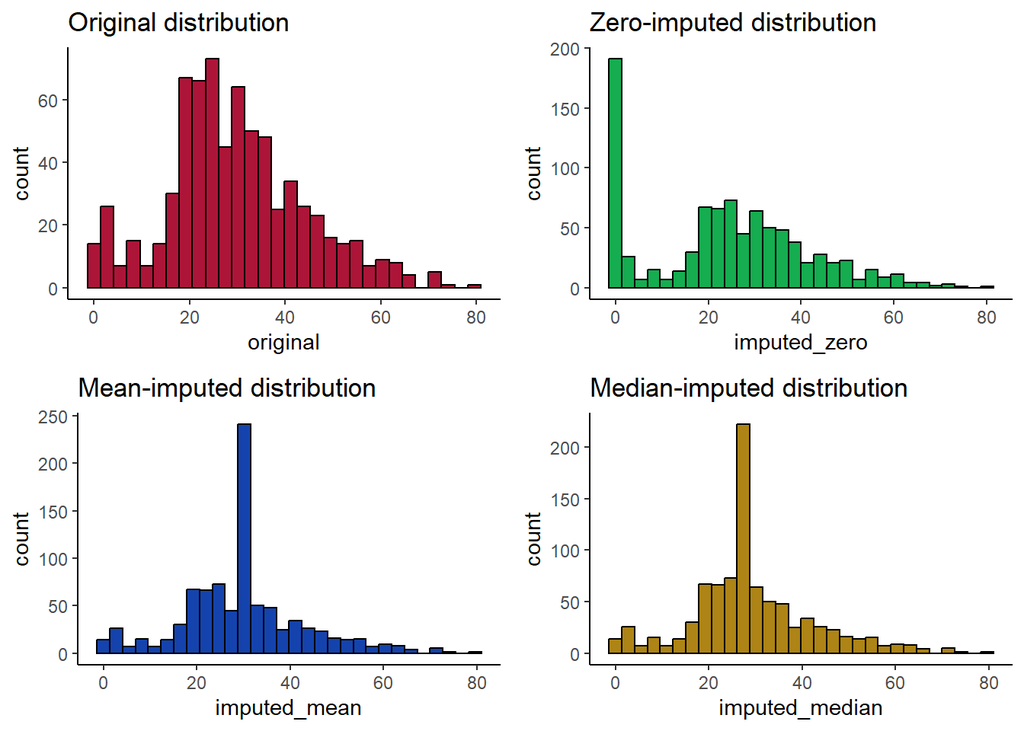

```r
h1 <- ggplot(value_imputed, aes(x = original)) +
  geom_histogram(fill = "#ad1538", color = "#000000", position = "identity") +
  ggtitle("Original distribution") +
  theme_classic()
h2 <- ggplot(value_imputed, aes(x = imputed_zero)) +
  geom_histogram(fill = "#15ad4f", color = "#000000", position = "identity") +
  ggtitle("Zero-imputed distribution") +
  theme_classic()
h3 <- ggplot(value_imputed, aes(x = imputed_mean)) +
  geom_histogram(fill = "#1543ad", color = "#000000", position = "identity") +
  ggtitle("Mean-imputed distribution") +
  theme_classic()
h4 <- ggplot(value_imputed, aes(x = imputed_median)) +
  geom_histogram(fill = "#ad8415", color = "#000000", position = "identity") +
  ggtitle("Median-imputed distribution") +
  theme_classic()

plot_grid(h1, h2, h3, h4, nrow = 2, ncol = 2)
```

## MICE

MICE stands for Multivariate Imputation via Chained Equations, and it’s one of the most common packages for R users. It assumes the missing values are missing at random (MAR). The basic idea behind the algorithm is to treat each variable that has missing values as a dependent variable in regression and treat the others as independent (predictors). The R mice packages provide many univariate imputation methods.

https://appsilon.com/imputation-in-r/#:~:text=Impute%20Missing%20Values%20in%20R%20with%20MICE&text=It%20assumes%20the%20missing%20values,others%20as%20independent%20(predictors).

We will be using the titanic data to learn about imputation package. ### Examine the data It is important to get a visual representation of missing data and variable distribution when examining new data.

```r
library(mice)
```

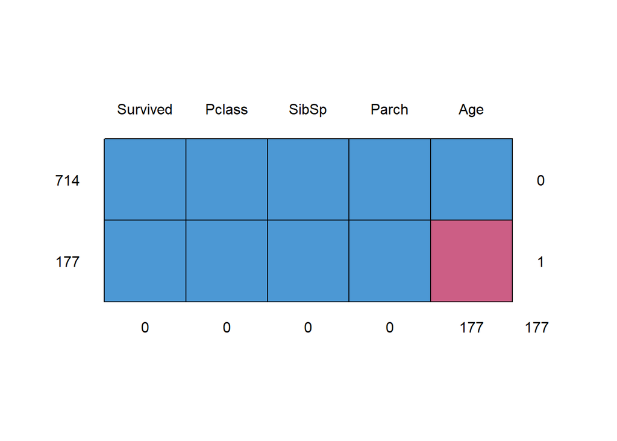

```
##     Survived Pclass SibSp Parch Age
## 714        1      1     1     1   1   0
## 177        1      1     1     1   0   1
##            0      0     0     0 177 177
```

```r
titanic_numeric <- titanic_train %>%
  select(Survived, Pclass, SibSp, Parch, Age)

md.pattern(titanic_numeric)
```

I prefer the `sapply` method. I shows the missing values clearly.

```r
sapply(titanic_numeric, function(x) sum(is.na(x)))
```

```
## Survived   Pclass    SibSp    Parch      Age
##        0        0        0        0      177
```

Onto the imputation now. We’ll use the following MICE imputation methods:

- pmm: Predictive mean matching.
- cart: Classification and regression trees.
- laso.norm: Lasso linear regression.

```r
mice_imputed <- data.frame(
  original = titanic_train$Age,
  imputed_pmm = complete(mice(titanic_numeric, method = "pmm"))$Age,
  imputed_cart = complete(mice(titanic_numeric, method = "cart"))$Age,
  imputed_lasso = complete(mice(titanic_numeric, method = "lasso.norm"))$Age
)
mice_imputed
```

| original | imputed_pmm | imputed_cart | imputed_lasso |
| --- | --- | --- | --- |
| 22.00 | 22.00 | 22.00 | 22.0000000 |
| 38.00 | 38.00 | 38.00 | 38.0000000 |
| 26.00 | 26.00 | 26.00 | 26.0000000 |
| 35.00 | 35.00 | 35.00 | 35.0000000 |
| 35.00 | 35.00 | 35.00 | 35.0000000 |
| NA | 41.00 | 33.00 | 24.7545763 |
| 54.00 | 54.00 | 54.00 | 54.0000000 |
| 2.00 | 2.00 | 2.00 | 2.0000000 |
| 27.00 | 27.00 | 27.00 | 27.0000000 |
| 14.00 | 14.00 | 14.00 | 14.0000000 |

[output cut: 881 more lines]

### Examine the new data

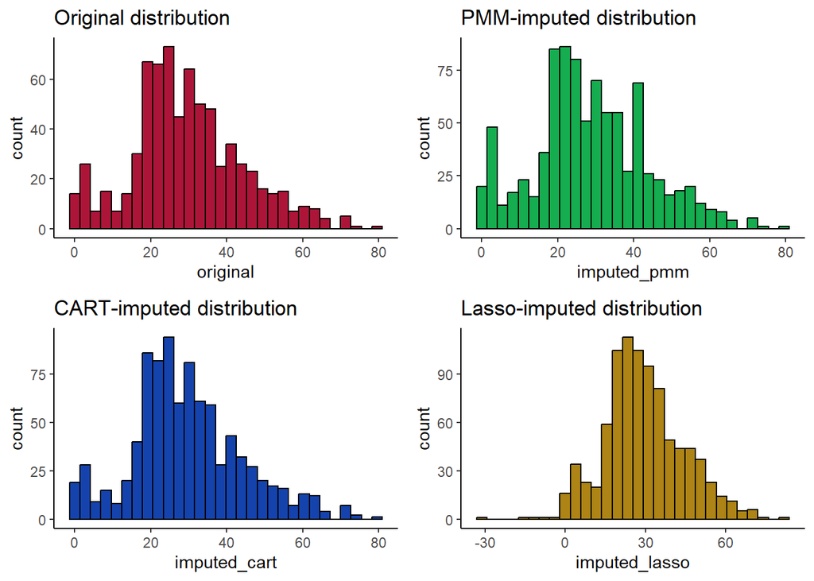

```r
h1 <- ggplot(mice_imputed, aes(x = original)) +
  geom_histogram(fill = "#ad1538", color = "#000000", position = "identity") +
  ggtitle("Original distribution") +
  theme_classic()
h2 <- ggplot(mice_imputed, aes(x = imputed_pmm)) +
  geom_histogram(fill = "#15ad4f", color = "#000000", position = "identity") +
  ggtitle("PMM-imputed distribution") +
  theme_classic()
h3 <- ggplot(mice_imputed, aes(x =  imputed_cart)) +
  geom_histogram(fill = "#1543ad", color = "#000000", position = "identity") +
  ggtitle("CART-imputed distribution") +
  theme_classic()
h4 <- ggplot(mice_imputed, aes(x = imputed_lasso)) +
  geom_histogram(fill = "#ad8415", color = "#000000", position = "identity") +
  ggtitle("Lasso-imputed distribution") +
  theme_classic()

plot_grid(h1, h2, h3, h4, nrow = 2, ncol = 2)
```

Note that there are negative ages that show in the lasso results. negative values will need to be corrected manually.

```r
head(dem.df2)
```

| PAT_MRN | PAT_DOB | RACE | ETHNICITY | SEX |
| --- | --- | --- | --- | --- |
| 923 | 4/5/2007 | White | Not Hispanic or Latino | Female |
| 942 | 9/1/2006 | NA | NA | Female |
| 356 | 11/26/2000 | White | Not Hispanic or Latino | Male |
| 844 | 11/28/2004 | Other | Not Hispanic or Latino | Female |
| 675 | 3/3/2013 | Black or African-American | Not Hispanic or Latino | Male |
| 564 | 12/13/2013 | White | Not Hispanic or Latino | Female |

## Add CURRENT_AGE column

The objective of this task is to learn how to copy, add, and calculate a new data to a df.

```r
dem.df2$CURRENT_AGE <- 0 # add the CURRENT_AGE column with 0 as a place holder value
head(dem.df2)
```

| PAT_MRN | PAT_DOB | RACE | ETHNICITY | SEX | CURRENT_AGE |
| --- | --- | --- | --- | --- | --- |
| 923 | 4/5/2007 | White | Not Hispanic or Latino | Female | 0 |
| 942 | 9/1/2006 | NA | NA | Female | 0 |
| 356 | 11/26/2000 | White | Not Hispanic or Latino | Male | 0 |
| 844 | 11/28/2004 | Other | Not Hispanic or Latino | Female | 0 |
| 675 | 3/3/2013 | Black or African-American | Not Hispanic or Latino | Male | 0 |
| 564 | 12/13/2013 | White | Not Hispanic or Latino | Female | 0 |

```r
# create the date variable
as.Date
```

```
## function (x, ...)
## UseMethod("as.Date")
## <bytecode: 0x000001dd01bdfee8>
## <environment: namespace:base>
```

```r
install.packages("tidyr")
library("tidyr")
dem.df2 %>% drop_na()
```

| PAT_MRN | PAT_DOB | RACE | ETHNICITY | SEX | CURRENT_AGE |
| --- | --- | --- | --- | --- | --- |
| 923 | 4/5/2007 | White | Not Hispanic or Latino | Female | 0 |
| 356 | 11/26/2000 | White | Not Hispanic or Latino | Male | 0 |
| 844 | 11/28/2004 | Other | Not Hispanic or Latino | Female | 0 |
| 675 | 3/3/2013 | Black or African-American | Not Hispanic or Latino | Male | 0 |
| 564 | 12/13/2013 | White | Not Hispanic or Latino | Female | 0 |
| 758 | 11/16/2005 | White | Not Hispanic or Latino | Female | 0 |
| 220 | 5/19/2002 | White | Not Hispanic or Latino | Male | 0 |
| 686 | 10/16/2004 | Black or African-American | Not Hispanic or Latino | Female | 0 |
| 728 | 8/6/2004 | White | Not Hispanic or Latino | Male | 0 |
| 507 | 8/12/2001 | White | Not Hispanic or Latino | Female | 0 |

[output cut: 271 more lines]

```r
# solution: Missing value where true/false needed
library("eeptools")
dem.df2$CURRENT_AGE <- dem.df2$PAT_DOB # copy a column
library(lubridate)
# make sure that the dates are in the same format
dem.df2$CURRENT_AGE <- as.Date(dem.df2$PAT_DOB, format = "%m/%d/%Y")
dem.df2$PAT_DOB <- as.Date(dem.df2$PAT_DOB, format = "%m/%d/%Y")
# convert to age in years
dem.df2$CURRENT_AGE <- age_calc(dem.df2$CURRENT_AGE, units = "years")
head(dem.df2)
```

| PAT_MRN | PAT_DOB | RACE | ETHNICITY | SEX | CURRENT_AGE |
| --- | --- | --- | --- | --- | --- |
| 923 | 2007-04-05 | White | Not Hispanic or Latino | Female | 16.38904 |
| 942 | 2006-09-01 | NA | NA | Female | 16.98082 |
| 356 | 2000-11-26 | White | Not Hispanic or Latino | Male | 22.74247 |
| 844 | 2004-11-28 | Other | Not Hispanic or Latino | Female | 18.74220 |
| 675 | 2013-03-03 | Black or African-American | Not Hispanic or Latino | Male | 10.47945 |
| 564 | 2013-12-13 | White | Not Hispanic or Latino | Female | 9.69863 |

# Pulling specific data from a df

Extract all female patients ages greater than or equal to 10.

```r
subset(dem.df2, SEX == 'Female' & CURRENT_AGE >= 10)
```

| PAT_MRN | PAT_DOB | RACE | ETHNICITY | SEX | CURRENT_AGE |
| --- | --- | --- | --- | --- | --- |
| 923 | 2007-04-05 | White | Not Hispanic or Latino | Female | 16.38904 |
| 942 | 2006-09-01 | NA | NA | Female | 16.98082 |
| 844 | 2004-11-28 | Other | Not Hispanic or Latino | Female | 18.74220 |
| 758 | 2005-11-16 | White | Not Hispanic or Latino | Female | 17.77260 |
| 686 | 2004-10-16 | Black or African-American | Not Hispanic or Latino | Female | 18.85969 |
| 507 | 2001-08-12 | White | Not Hispanic or Latino | Female | 22.03562 |
| 964 | 2004-06-09 | Other | Not Hispanic or Latino | Female | 19.21096 |
| 203 | 2009-10-08 | White | Not Hispanic or Latino | Female | 13.87945 |
| 518 | 2013-06-22 | White | Not Hispanic or Latino | Female | 10.17534 |
| 895 | 2006-06-07 | White | Not Hispanic or Latino | Female | 17.21644 |

[output cut: 125 more lines]

# Plots

```r
library("tidyverse")
dem.df2 %>% count(SEX)
```

| SEX | n |
| --- | --- |
| Female | 148 |
| Male | 151 |
| NA | 1 |

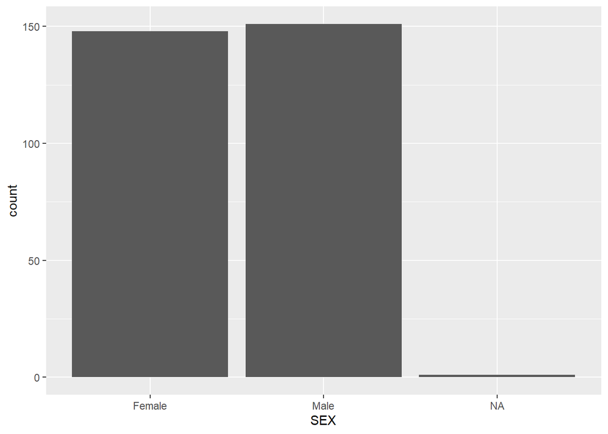

```r
ggplot(data = dem.df2) +
  geom_bar(mapping = aes(x = SEX)) # simple bar graph
```

# Exporting data

This is the template to export data. `write.csv(DataFrame Name, "Path to export the DataFrame\\File Name.csv", row.names=FALSE)`

```r
# Load readr package
library("readr")
```

```r
write_csv(dem.df2, "new_patientdem.csv")
```

# Resources

https://www.r-bloggers.com/2021/04/handling-missing-values-in-r/ https://stackoverflow.com/questions/27096485/change-a-column-from-birth-date-to-age-in-r <[https://sparkbyexamples.com/r-programming/r-subset-data-frame-with-examples/#:\~:text=If%20you%20wanted%20to%20get,variables)%20from%20the%20data%20frame.]>

https://michaelgastner.com/R_for_QR/extracting-values-from-data-frames.html https://community.rstudio.com/t/dplyr-way-s-and-base-r-way-s-of-creating-age-group-from-age/89226/3 https://www.datanovia.com/en/lessons/subset-data-frame-rows-in-r/ https://r4ds.had.co.nz/data-visualisation.html https://www.infoworld.com/article/3573577/how-to-count-by-groups-in-r.html https://dplyr.tidyverse.org/reference/mutate.html

https://sparkbyexamples.com/r-programming/r-export-csv-using-write-csv/